# BIOS 667 - Lecture 5: Modeling the Mean - Response Profiles (Ch. 5)

# Part II (Day 2): Baseline Strategies, Strengths, and Computing

# Section 4: Baseline Value Strategies

## Four Strategies for Baseline Handling

| Strategy | Description |
| --- | --- |
| 1 | Retain baseline; no equality assumption |
| 2 | Retain baseline; constrain groups equal at baseline (RCT) |
| 3 | Analyze change-from-baseline: $\Delta_{ij} = Y_{ij} - Y_{i1}$ |
| 4 | ANCOVA: use $Y_{i1}$ as covariate for post-baseline responses |

## Strategy 1: Retain Baseline, No Equality

Fit the LM with all times, no constraint at $t=1$:

$$E(\mathbf{Y}_i \mid \mathbf{X}_i) = \mathbf{X}_i \boldsymbol{\beta}$$

where $\mu_1^{(1)}, \ldots, \mu_1^{(G)}$ are free parameters.

## Strategy 1: Pros and Cons

| Pros | Cons |
| --- | --- |
| Minimal assumptions | Main “group” effect hard to interpret if baseline levels differ |
| Natural for observational data | May be less efficient than approaches exploiting baseline balance |
| Uses all information |  |

## Strategy 2: Constrain Equal at Baseline

Appropriate in **randomized trials** (baseline pre-randomization).

Add constraint:

$$\mu_1^{(1)} = \mu_1^{(2)} = \cdots = \mu_1^{(G)}$$

## Strategy 2: Pros and Cons

| Pros | Cons |
| --- | --- |
| Reflects randomization | Invalid if baseline equality fails |
| Often yields greater precision | Sensitivity to constraint violation |
| Clean interpretation of group differences |  |

## Strategy 3: Change-from-Baseline

Define subject-level differences:

$$\Delta_{ij} = Y_{ij} - Y_{i1}, \quad j = 2, \ldots, n$$

Or use a univariate summary:

$$Y_i^* = \frac{1}{n-1}\sum_{j=2}^n (Y_{ij} - Y_{i1})$$

## Strategy 3: Pros and Cons

| Pros | Cons |
| --- | --- |
| Intuitive change estimand | Can be less efficient than ANCOVA when $\rho < 1$ |
| Avoids modeling baseline as covariate | Forces the baseline coefficient to exactly 1, instead of the optimal value |
| Simpler tests ($G-1$ df) | Loses information about absolute levels |

## Strategy 4: ANCOVA

Univariate ANCOVA on average post-baseline response:

$$Y_i^* = \alpha + \beta \cdot \text{trt}_i + \gamma \cdot Y_{i1} + \varepsilon_i$$

Or time-specific repeated-measures ANCOVA:

$$Y_{ij} = \alpha_j + \beta_j \cdot \text{trt}_i + \gamma_j \cdot Y_{i1} + \varepsilon_{ij}, \quad j \ge 2$$

## Strategy 4: Pros and Cons

| Pros | Cons |
| --- | --- |
| In RCTs, typically more efficient | In observational data, may induce Lord’s paradox (next slide) |
| Adjusts for random baseline variability | Requires linearity and homogeneous slopes |
| Smaller SEs for group effect | Measurement error in $Y_{i1}$ can bias $\gamma$ |

## Lord’s Paradox (beyond FLW Ch. 5)

**Instructor extension, not in FLW Ch. 5**

**Lord’s paradox:** when two groups differ at baseline, change-score analysis and ANCOVA can give **opposite-signed** group effects on the same data. Neither is “wrong”; they answer different questions (unconditional change vs. baseline-conditional difference).

```
            change score says:            ANCOVA says:
   group A  ---- no change (flat) ----     conditional on baseline,
   group B  ---- no change (flat) ----     A and B differ in outcome
   (groups start at different baselines)   (regression line tilts the comparison)
   => "no group effect"                    => "group effect" (opposite conclusion)
```

The two methods point in different directions precisely because the groups are not comparable at baseline (no randomization).

Lord, F.M. (1967). A paradox in the interpretation of group comparisons. *Psychological Bulletin* 68(5):304-305.

## Relative Efficiency: Change vs. ANCOVA

Under compound symmetry with variance $\sigma^2$ and correlation $\rho$, with **one baseline and one post-baseline occasion** ($n = 2$):

$$\text{RE} = \frac{\text{Var}(\hat\beta_{\text{Change}})}{\text{Var}(\hat\beta_{\text{ANCOVA}})} = \frac{2}{1 + \rho}$$

This is the single-follow-up special case. The general $n$-occasion result (FLW eq. (5.3), Section 5.6) gives the efficiency of the change-score summary **relative to ANCOVA** as

$$\frac{1}{n}\{1 + (n-1)\rho\} < 1,$$

so ANCOVA is $\dfrac{n}{1 + (n-1)\rho}$ times as efficient (at $n = 2$ this is $2/(1+\rho)$). ANCOVA’s advantage grows BOTH as $\rho$ decreases AND as the number of occasions $n$ increases (an $n$-fold gain as $\rho \to 0$).

**Why ANCOVA wins:** a change score writes $Y_f - 1 \cdot Y_1$, forcing the baseline coefficient to exactly **1**. ANCOVA fits $Y_f - \gamma \cdot Y_1$ and **estimates the optimal** $\gamma$ (here $\gamma \approx \rho$), the regression-to-the-mean adjustment. Pinning $\gamma = 1$ is generally not optimal, so change scores carry extra variance.

## Relative Efficiency: Implications

The table below is the **single-follow-up ($n = 2$) special case** $\text{RE} = 2/(1+\rho)$:

| Condition | Relative Efficiency ($n = 2$) |
| --- | --- |
| $\rho = 0$ | RE = 2 (change scores twice as variable) |
| $\rho = 0.5$ | RE = 4/3 $\approx$ 1.33 |
| $\rho = 0.8$ | RE = 10/9 $\approx$ 1.11 |
| $\rho \to 1$ | RE $\to$ 1 (methods become equivalent) |

RE $\geq 1$ always, so ANCOVA is always at least as efficient as change scores. With more occasions the gap is larger still: by FLW eq. (5.3) ANCOVA is $n/\{1+(n-1)\rho\}$ times as efficient, up to $n$-fold as $\rho \to 0$.

## Decision Guide: When to Use Which?

| Study Type | Recommended Strategy |
| --- | --- |
| Randomized trial | Strategy 4 (ANCOVA) or Strategy 2 for power and clarity |
| Observational | Strategy 1 or Strategy 3 for unconditional change questions |
|  | Strategy 4 only if conditional estimand is intended |

## Estimand Matters

**Tip**

- **Strategy 3** tests whether groups differ in mean change (unconditional)
- **Strategy 4** tests whether individuals matched on baseline differ in expected outcome (conditional)

## When to Use Alternatives

| Situation | Alternative Approach |
| --- | --- |
| Irregular timing | LMM with random effects; AR(1), SP[POW] |
| Trend focus | Parametric/spline-by-group (Ch. 6) |
| Population-average | GEE (robust SE) |
| Large $n$ vs. $N$ | Structured $\Sigma$ / shrinkage |

## Rule of Thumb Summary

| Study Design | Recommendation |
| --- | --- |
| RCT | Strategy 2 or 4; Strategy 4 typically more efficient |
| Observational | Strategy 1 for flexible profiling; Strategy 3 for unconditional change; Strategy 4 only when conditional estimand is intended |

## Mini Demo: Change vs. ANCOVA

```r
set.seed(7)
n <- 120
group <- factor(rep(c("Control","Treatment"), each=n/2))
Y1 <- rnorm(n, 20, 4)                 # baseline
# True model: follow-up depends on baseline + treatment effect
Yf <- 5 + 0.6*Y1 + 2*(group=="Treatment") + rnorm(n, 0, 3)

# Change score and ANCOVA
change <- Yf - Y1
fit_change <- lm(change ~ group)
fit_ancova <- lm(Yf ~ group + Y1)

summary(fit_change)$coef
```

## Mini Demo: Change vs. ANCOVA

```
                Estimate Std. Error   t value     Pr(>|t|)
(Intercept)    -3.007057  0.4422887 -6.798856 4.589559e-10
groupTreatment  1.777856  0.6254906  2.842338 5.278475e-03
```

```r
summary(fit_ancova)$coef
```

```
                Estimate Std. Error  t value     Pr(>|t|)
(Intercept)    7.3910799 1.50814467 4.900776 3.100294e-06
groupTreatment 1.5311091 0.52598210 2.910953 4.315220e-03
Y1             0.5016241 0.07006171 7.159748 7.686620e-11
```

## Takeaway: Comparing the Two Treatment-Effect SEs

```r
se_change <- summary(fit_change)$coef["groupTreatment", "Std. Error"]
se_ancova <- summary(fit_ancova)$coef["groupTreatment", "Std. Error"]
rho_hat   <- cor(Y1, Yf)

c(SE_change = se_change, SE_ancova = se_ancova,
  ratio_SE2 = (se_change^2) / (se_ancova^2),   # empirical variance ratio
  RE_formula = 2 / (1 + rho_hat))              # 2/(1+rho)
```

The change-score SE is the larger of the two. This demo has a single follow-up, so the empirical variance ratio tracks the $n = 2$ formula $\text{RE} = 2/(1+\rho)$ (the special case of FLW eq. (5.3)): ANCOVA wins because it estimates the **optimal** baseline coefficient instead of forcing it to 1. The gap is largest at low $\rho$ and vanishes as $\rho \to 1$ (decreasing in $\rho$); with more occasions the gap grows toward $n$-fold.

## Takeaway: Comparing the Two Treatment-Effect SEs

```
 SE_change  SE_ancova  ratio_SE2 RE_formula
 0.6254906  0.5259821  1.4141637  1.3080273
```

## Baseline Value Strategy Summary

| Strategy | Key Feature |
| --- | --- |
| 1 | Flexible; good for observational; may be less efficient |
| 2 | Uses RCT baseline equality; more precise if valid |
| 3 | Intuitive changes; simpler tests; may be inefficient |
| 4 | Most powerful in RCTs; in observational data watch for Lord’s paradox (defined earlier) |

**Bottom line:** Let design + scientific question dictate the strategy.

**Check Your Understanding: Baseline Strategies**

1. In a randomized trial, which baseline strategy is typically most efficient and why?
2. What is the key assumption behind Strategy 2 (constraining groups equal at baseline)?
3. Why might change-from-baseline (Strategy 3) be less efficient than ANCOVA (Strategy 4)?

**Answers:**

1. **Strategy 4 (ANCOVA)** - it adjusts for random baseline variability, reducing residual variance and yielding smaller standard errors for the treatment effect
2. Groups have equal mean response at baseline (valid by randomization in RCTs, but potentially violated in observational studies)
3. A change score is $Y_f - 1 \cdot Y_1$: it forces the baseline coefficient to exactly 1. ANCOVA fits $Y_f - \gamma Y_1$ and estimates the optimal $\gamma$ (the regression-to-the-mean coefficient, about $\rho$). Pinning $\gamma=1$ is generally suboptimal, so change scores carry extra variance. With a single follow-up ($n = 2$) the loss follows $\text{RE} = 2/(1+\rho)$, shrinking to nothing as $\rho \to 1$; in general (FLW eq. (5.3)) ANCOVA is $n/\{1+(n-1)\rho\}$ times as efficient, so its advantage grows as $\rho$ falls and as the number of occasions $n$ grows.

# Section 5: Strengths and Weaknesses

## Strengths of Response Profile Analysis

- Balanced designs with common measurement times
- Arbitrary mean structure + unstructured $\Sigma$
- Avoids covariance misspecification by leaving $\Sigma$ unstructured (no working-correlation assumption)
- Works with balanced-incomplete data
- Discrete covariates via the LM; contrasts/AUC

**Note**

Leaving $\Sigma$ free protects against COVARIANCE misspecification; the SEs here are model-based (from the fitted $\Sigma$), not sandwich/empirical. The MEAN model can still be misspecified, so this is not a blanket robustness claim.

## Comparison with MANOVA

| MANOVA | Response Profiles |
| --- | --- |
| Complete cases only | Handles missing data |
| Test-heavy approach | Estimands + estimation first |
|  | Flexible baseline handling |

## Weaknesses of Response Profile Analysis

- Requires balanced timing; poor for mistimed visits
- Ignores time ordering; omnibus tests need follow-up
- Lower power for specific trends (prefer 1 df tests)
- Parameter growth: $Gn + \frac{n(n+1)}{2}$

## Parameter Growth Example ($G=2$)

```r
param_counts <- function(G, n) G*n + n*(n+1)/2
data.frame(n=c(3,10), total_params=param_counts(2, c(3,10)))
```

## Parameter Growth Example ($G=2$)

```
   n total_params
1  3           12
2 10           75
```

# Section 6: R Computing Example

## Computing Goals

- Replicate PROC MIXED response-profiles analysis in R
- Model: $Y_{ij} \sim \text{group} \times \text{time}$
- Unstructured within-subject covariance
- Use `nlme::gls()` with `corSymm` + `varIdent`

## Read and Prepare Data

```r
library(dplyr); library(tidyr); library(nlme); library(ggplot2)
if (requireNamespace("emmeans", quietly = TRUE)) library(emmeans)

# Path to data file
path <- "../../data/tlc.csv"

# Read and rename columns
tlc_wide <- read.csv(path, check.names = FALSE, stringsAsFactors = FALSE)
names(tlc_wide) <- trimws(names(tlc_wide))

tlc_wide <- tlc_wide %>%
  rename(
    id  = ID,
    trt = `Treatment Group`,
    w0  = `Lead Level Week 0`,
    w1  = `Lead Level Week 1`,
    w4  = `Lead Level Week 4`,
    w6  = `Lead Level Week 6`
  ) %>%
  mutate(trt = factor(trt, levels = c("P","A"), labels = c("Placebo","Succimer")))

head(tlc_wide)
```

## Read and Prepare Data

```
  id      trt   w0   w1   w4   w6
1  1  Placebo 30.8 26.9 25.8 23.8
2  2 Succimer 26.5 14.8 19.5 21.0
3  3 Succimer 25.8 23.0 19.1 23.2
4  4  Placebo 24.7 24.5 22.0 22.5
5  5 Succimer 20.4  2.8  3.2  9.4
6  6 Succimer 20.4  5.4  4.5 11.9
```

## Reshape: Wide to Long

```r
tlc_long <- tlc_wide %>%
  pivot_longer(cols = c(w0, w1, w4, w6),
               names_to = "wk", values_to = "y") %>%
  mutate(
    time = recode(wk, w0 = "0", w1 = "1", w4 = "4", w6 = "6"),
    time = factor(time, levels = c("0","1","4","6")),
    group = trt
  ) %>%
  arrange(id, time) %>%
  select(id, group, time, y)

head(tlc_long)
```

## Reshape: Wide to Long

```
# A tibble: 6 × 4
     id group    time      y
  <int> <fct>    <fct> <dbl>
1     1 Placebo  0      30.8
2     1 Placebo  1      26.9
3     1 Placebo  4      25.8
4     1 Placebo  6      23.8
5     2 Succimer 0      26.5
6     2 Succimer 1      14.8
```

## How `gls()` Builds an Unstructured Covariance

**UN = `corSymm` + `varIdent`**

`nlme` has no single “UN” option. You build it from two pieces:

- `corSymm(form = ~ as.numeric(time) | id)`: **free correlations** among occasions (the off-diagonal of the correlation matrix, all estimated separately).
- `varIdent(form = ~ 1 | time)`: a **separate variance per occasion** (heteroscedastic diagonal).

Together these give a fully unstructured $\Sigma$. The `as.numeric(time) | id` part sets the **within-subject ordering**: it tells `gls()` which occasion each row is and that rows sharing an `id` form one subject’s vector. Omit it and the correlations are mis-aligned.

## Fit Response Profiles (UN Covariance)

```r
# Unstructured covariance = free correlations (corSymm) + per-occasion variances (varIdent)
fit_un_REML <- gls(
  y ~ group * time,
  data = tlc_long,
  correlation = corSymm(form = ~ as.numeric(time) | id),  # free correlations; sets within-id order
  weights     = varIdent(form = ~ 1 | time),               # one variance per occasion
  method = "REML",
  na.action = na.omit
)

summary(fit_un_REML)
```

## Fit Response Profiles (UN Covariance)

```
Generalized least squares fit by REML
  Model: y ~ group * time
  Data: tlc_long
       AIC      BIC    logLik
  2452.076 2523.559 -1208.038

Correlation Structure: General
 Formula: ~as.numeric(time) | id
 Parameter estimate(s):
 Correlation:
  1     2     3
2 0.571
3 0.570 0.775
4 0.577 0.582 0.581
Variance function:
 Structure: Different standard deviations per stratum
 Formula: ~1 | time
 Parameter estimates:
       0        1        4        6
1.000000 1.325877 1.370472 1.524816

Coefficients:
                      Value Std.Error   t-value p-value
(Intercept)          26.272 0.7102892  36.98775  0.0000
groupSuccimer         0.268 1.0045006   0.26680  0.7898
time1                -1.612 0.7919151  -2.03557  0.0425
time4                -2.202 0.8149220  -2.70210  0.0072
time6                -2.626 0.8885196  -2.95548  0.0033
groupSuccimer:time1 -11.406 1.1199371 -10.18450  0.0000
groupSuccimer:time4  -8.824 1.1524737  -7.65657  0.0000
groupSuccimer:time6  -3.152 1.2565565  -2.50844  0.0125

 Correlation:
                    (Intr) grpScc time1  time4  time6  grpS:1 grpS:4
groupSuccimer       -0.707
time1               -0.218  0.154
time4               -0.191  0.135  0.680
time6               -0.096  0.068  0.386  0.385
groupSuccimer:time1  0.154 -0.218 -0.707 -0.481 -0.273
groupSuccimer:time4  0.135 -0.191 -0.481 -0.707 -0.272  0.680
groupSuccimer:time6  0.068 -0.096 -0.273 -0.272 -0.707  0.386  0.385

Standardized residuals:
       Min         Q1        Med         Q3        Max
-2.1756520 -0.6850000 -0.1515556  0.5294195  5.6327738

Residual standard error: 5.022503
Degrees of freedom: 400 total; 392 residual
```

## Test Group x Time (Parallelism)

```r
# Use ML for fixed-effect LRTs
fit_full_ML   <- update(fit_un_REML, method = "ML")
fit_no_int_ML <- update(fit_full_ML, . ~ group + time)

anova(fit_no_int_ML, fit_full_ML)  # df = (G-1)*(n-1)
```

## Test Group x Time (Parallelism)

```
              Model df      AIC      BIC    logLik   Test  L.Ratio p-value
fit_no_int_ML     1 15 2529.555 2589.427 -1249.778
fit_full_ML       2 18 2461.368 2533.214 -1212.684 1 vs 2 74.18778  <.0001
```

## Interpreting the Parallelism Test

**In plain language:** The likelihood ratio test compares:

- **Full model:** Separate mean for each group-by-time combination (allows non-parallel profiles)
- **Reduced model:** Main effects only (forces parallel profiles)

A significant p-value (e.g., p < 0.05) indicates that profiles are **not parallel** - the treatment effect differs across time points. In the TLC trial, this would mean Succimer’s effect is not constant over time (as suggested by the sharp drop then rebound).

## Estimated Response Profiles

```r
if (requireNamespace("emmeans", quietly = TRUE)) {
  emm <- emmeans::emmeans(fit_un_REML, ~ group * time)
  emm_df <- as.data.frame(emm)

  print(ggplot(emm_df, aes(x = time, y = emmean, group = group, shape = group)) +
    geom_line() + geom_point(size = 2) +
    labs(y = "Estimated mean blood lead (µg/dL)",
         title = "TLC Trial: Estimated Response Profiles (UN covariance)") +
    theme_minimal())
} else {
  # Alternative: compute fitted values from the model
  newdata <- expand.grid(group = levels(tlc_long$group),
                         time = levels(tlc_long$time))
  newdata$emmean <- predict(fit_un_REML, newdata = newdata)

  print(ggplot(newdata, aes(x = time, y = emmean, group = group, shape = group)) +
    geom_line() + geom_point(size = 2) +
    labs(y = "Estimated mean blood lead (µg/dL)",
         title = "TLC Trial: Estimated Response Profiles (UN covariance)") +
    theme_minimal())
}
```

## Estimated Response Profiles

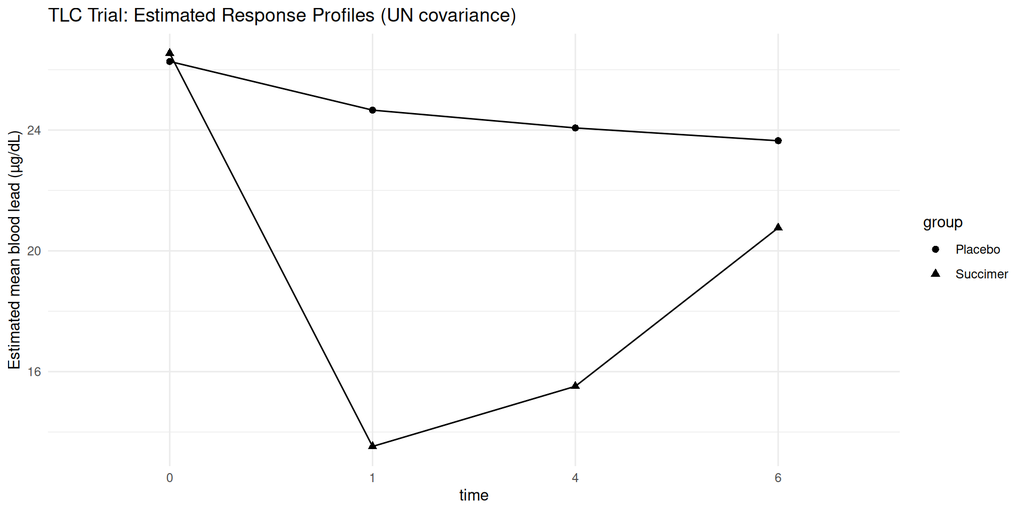

## Reading Off the Covariance: the $\Sigma_i = \mathbf{S}\,\mathbf{C}\,\mathbf{S}$ Identity

`gls()` stores the covariance in two pieces, so we reassemble it from:

$$\Sigma_i = \mathbf{S}\,\mathbf{C}\,\mathbf{S}$$

- $\mathbf{S}$ = diagonal of **occasion-specific standard deviations** (from `varIdent`).
- $\mathbf{C}$ = the **correlation matrix** among occasions (from `corSymm`).

(We use $\mathbf{S}$/$\mathbf{C}$ for the SD-correlation split here so as not to collide with the reserved $G$ = random-effects covariance and $R_i$ = residual covariance of Ch. 8.)

So a per-occasion SD on the diagonal times the free correlations rebuilds the full unstructured $\Sigma_i$.

## Extract UN Covariance Matrix (advanced / reference)

```r
# --- S: occasion-specific SDs (from varIdent) ---
lev <- levels(tlc_long$time)
# varIdent reports a multiplier for each NON-reference occasion; the
# reference occasion (here "0") is fixed at 1 and is NOT in this vector.
vmult <- coef(fit_un_REML$modelStruct$varStruct, unconstrained = FALSE)
sd_mult <- setNames(rep(1, length(lev)), lev)  # start all at the reference value 1
sd_mult[names(vmult)] <- vmult                 # fill in the estimated multipliers by NAME
SDdiag <- diag(fit_un_REML$sigma * sd_mult)    # S = base sigma * per-occasion multiplier

# --- C: correlation among occasions (from corSymm) ---
Rhat <- corMatrix(fit_un_REML$modelStruct$corStruct)[[1]]

# --- Sigma = S C S ---
Sigma_hat <- SDdiag %*% Rhat %*% SDdiag
dimnames(Sigma_hat) <- list(lev, lev)
round(Sigma_hat, 2)
```

**Order-sensitivity (the part that bites)**

`varIdent` omits the reference occasion, so you must insert its multiplier of 1 **by name**, not by position; otherwise the reference occasion becomes `NA`. Likewise index everything by `levels(time)` so $\mathbf{S}$ and $\mathbf{C}$ share the same occasion order before multiplying. A positional reindex silently scrambles the rows.

## Extract UN Covariance Matrix (advanced / reference)

```
      0     1     4     6
0 25.23 19.11 19.70 22.20
1 19.11 44.35 35.54 29.67
4 19.70 35.54 47.38 30.62
6 22.20 29.67 30.62 58.65
```

## Replicate Figure 5.1: Raw Group Means

```r
means <- tlc_long %>%
  group_by(group, time) %>%
  summarise(mean_y = mean(y, na.rm = TRUE), .groups = "drop") %>%
  mutate(week = as.numeric(as.character(time)))

ggplot(means, aes(x = week, y = mean_y, group = group, shape = group)) +
  geom_line() + geom_point(size = 2) +
  scale_x_continuous(breaks = c(0,1,4,6)) +
  labs(x = "Time (weeks)", y = "Mean blood lead (µg/dL)",
       title = "TLC Trial: Mean Blood Lead by Group and Time") +
  theme_minimal()
```

## Replicate Figure 5.1: Raw Group Means

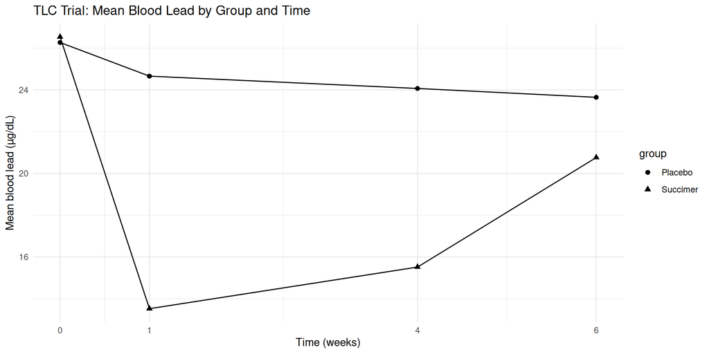

## Baseline-Adjusted ANCOVA (Section 5.6)

Subject-level model:

$$Y_i^* = \frac{w1_i + w4_i + w6_i}{3}$$

$$Y_i^* = \alpha + \beta \cdot \text{group}_i + \gamma \cdot w0_i + \varepsilon_i$$

## ANCOVA Implementation

```r
dat_subj <- tlc_wide %>%
  transmute(
    id,
    group = trt,
    w0, w1, w4, w6,
    Ystar = rowMeans(cbind(w1, w4, w6), na.rm = TRUE)
  )

fit_ancova <- lm(Ystar ~ group + w0, data = dat_subj)
summary(fit_ancova)$coef
```

## ANCOVA Implementation

```
                Estimate Std. Error   t value     Pr(>|t|)
(Intercept)    2.9456651  2.5558287  1.152528 2.519365e-01
groupSuccimer -7.7420533  0.9348417 -8.281673 6.739031e-13
w0             0.8061689  0.0939757  8.578482 1.559673e-13
```

## ANCOVA Output: Interpretation

**In plain language:** The coefficient output shows:

- **Intercept:** Expected average post-baseline lead level when baseline = 0 and group = reference (Placebo)
- **groupSuccimer:** The treatment effect - the difference in average post-baseline lead level for Succimer vs. Placebo, **adjusted for baseline**
- **w0:** The slope relating baseline to follow-up - a positive value means higher baseline is associated with higher follow-up

A negative, significant coefficient for `groupSuccimer` indicates that Succimer reduces blood lead levels compared to Placebo, after accounting for baseline differences.

## Same Analysis in SAS: Complete PROC MIXED Program

The R `gls()` fit above corresponds to this standalone SAS program (static, not run here):

```sas
/* TLC response-profiles analysis: unstructured covariance */
proc mixed data=tlc_long method=reml;
    class id group time;
    model y = group time group*time / s chisq;
    repeated time / type=un subject=id r rcorr;
run;
```

- `class` declares the categorical factors (set `id`, `group`, `time` as classification variables).
- `model y = group time group*time` is the saturated cell-means mean model.
- `repeated time / type=un subject=id` is the **unstructured** within-subject covariance (the `corSymm` + `varIdent` pair in R).
- The **`group*time` row of the “Type 3 Tests of Fixed Effects” table is the parallelism test** ($(G-1)(n-1)$ df, here $1\times 3 = 3$ for 2 groups and 4 weeks). The `chisq` option (REML default, no `ddfm=`) reports this as a **Wald chi-square (CHISQ) parallelism test**, matching FLW Table 5.11. It is not a likelihood-ratio test. (No hand-written `contrast` is needed; the Type 3 test already carries the correct df.)
- The R workflow above instead uses an **ML likelihood-ratio test** (`anova()` on two `method="ML"` fits). For an exact SAS analogue of that LRT, refit the full and no-interaction models with `method=ml` and compare $-2\log L$; the Wald chi-square and LR tests target the same hypothesis but are different statistics.

## SAS to R Cheat Sheet

| SAS | R |
| --- | --- |
| `CLASS id group time;` | Set factor levels (baseline first, Placebo as reference) |
| `MODEL y = group time group*time / S CHISQ;` | `gls(y ~ group * time, ...)` |
| `REPEATED time / TYPE=UN SUBJECT=id;` | `corSymm(~ as.numeric(time) \| id) + varIdent(~ 1 \| time)` |
| `METHOD=ML` (for LRTs) | `method="ML"` |
| Default REML | `method="REML"` |

## Common Mistakes to Avoid

- **Interpreting main effects when interaction is significant**: If parallelism ($H_{01}$) is rejected, main effects for group and time are misleading - the effect depends on the level of the other factor
- **Forgetting to set factor levels correctly**: R’s default is to use alphabetical ordering; set the reference level explicitly (e.g., Placebo before Treatment)
- **Using ANCOVA in observational studies without considering Lord’s paradox** (defined earlier): with unequal baselines, change-score and ANCOVA conclusions can point in opposite directions
- **Ignoring the relative efficiency of baseline strategies**: Change scores can be substantially less efficient than ANCOVA when baseline-outcome correlation is low
- **Applying response profiles to irregular visit times**: This approach assumes common measurement occasions; use parametric curves (Ch. 6) for irregular timing

## Summary

- Response profiles provide a flexible framework for balanced longitudinal data
- Test parallelism ($H_{01}$) before interpreting main effects
- Choose baseline handling strategy based on study design and estimand
- The general linear model (LM) with unstructured covariance maximizes flexibility
- R’s `nlme::gls()` replicates SAS PROC MIXED functionality